# Report on JustGiving in the wake of the Covid-19 pandemic

List of Effective charities

| Charity Name | Observations |
| --- | --- |
| WaterAid | 6664 |
| Unicef UK | 4950 |
| Oxfam | 3788 |
| CARE International UK | 1312 |
| Cool Earth | 308 |
| Sightsavers | 262 |
| Medecins Sans Frontieres / Doctors Without Borders (MSF) | 224 |
| Malaria No More UK | 131 |
| Malaria Consortium | 81 |
| Médecins Sans Frontières (UK) | 70 |
| Animal Equality | 16 |
| Evidence Action | 11 |
| Imperial College | 5 |
| Population Services International | 1 |

From these charities various data has been collected. Feature extraction has been performed to give insightful statistics about fundraisers and donations. Our dataset contains information on 44 variables. The descriptions of these variables are given below.

Variable descriptions

| activity_type | The type of activity that the fundraiser involves. |
| --- | --- |
| charity_created | Whether the fundraiser was set up by a registered charity or not. |
| charity_id | Each charity has a unique identification number. |
| charity_name | NULL |
| count_don | The number of donations that a page has received. |
| country_code | NULL |
| created_date | When the fundraiser was created (YMD-HMS) |
| date_created | When the fundraiser was created (YMD) |
| date_downloaded | The date downloaded indicates the date when the data was pulled from the JustGiving API. |
| don1_date | The date on which the first donation was made. |
| download_dur | The number of days between the date when the data was downloaded and the expiry date. |
| dur_cd_95 | The number of days between the fundraiser being created (created_date) and said fundraiser reaching over 95% of the page’s total donations. |
| dur_cdate | The number of days between the date when the fundraiser was created (created_date) and the date on which the first donation was received. |
| dur_ed_95 | The number of days between the event date and the date on which the fundraiser reached over 95% of total donations. |
| dur_edate | The number of days between the date of the event (event_date) and the date on which the first donation was received. |
| event_date | The date of the fundraiser event. |
| event_dur | The number of days between a fundraisers creation and the event date. |
| event_name | NULL |
| expiry_date | The date on which the page will no longer be able to receive donations on the JustGiving site. |
| expiry_dur | The number of days between the creation of a fundraiser and the date when the page expires. |
| first_downloaded | When the data was first downloaded from the JustGiving API. |
| fundraising_target | The target which has been set for the fundraiser to raise. |
| grand_total_raised_excluding_gift_aid | The total that the page raised without gift aid. |
| high_don | The highest donation that a page received. |
| hit_target | A binary indicator of whether or not a page reached it’s target. |
| hr_created | The hour that the fundraiser was created. |
| med_don | The median donation for a page. |
| mn_don | The mean donation for a page. |
| mo_created | The month that the fundraiser was created. |
| owner | NULL |
| page_short_name | The unique page name for the fundraiser, effectively a page ID. |
| perc_raised | The percentage that a fundraiser has raised, not including gift-aid. |
| prior_2020 | Whether the page was downloaded from the API before 2020 or not. |
| pull_dur | The number of days between a fundraisers creation and the next data pull. |
| status | Active - Donations can still be made. Expired - donations cannot be made. |
| sum_don | The total donations that a page received. |
| total_estimated_gift_aid | The total amount of gift aid raised. |
| total_raised | The total that a page raised. |
| total_raised_offline | The total that a page raised from offline donations. |
| total_raised_percentage_of_fundraising_target | The percentage of the pages target that was raised. |
| uk_lockdown | Whether the page was created during the UK’s national Coronavirus lockdown. |
| wday_created | The day of the week on which the page was created. |
| wk_created | Which week of the year that the page was created in. |
| yr_created | The year when the page was created. |

### Missing values

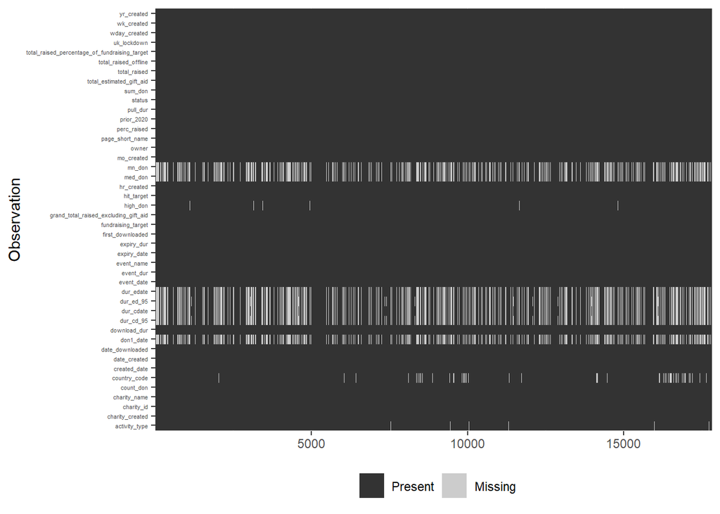

There are a high number of missing values for our duration variables. This is not surprising as 5679 pages did not receive any donations therefore meaning that statistics such as *“The number of days between the date of the event (event_date) and the date on which the first donation was received.”* do not exist.

### Date distributions

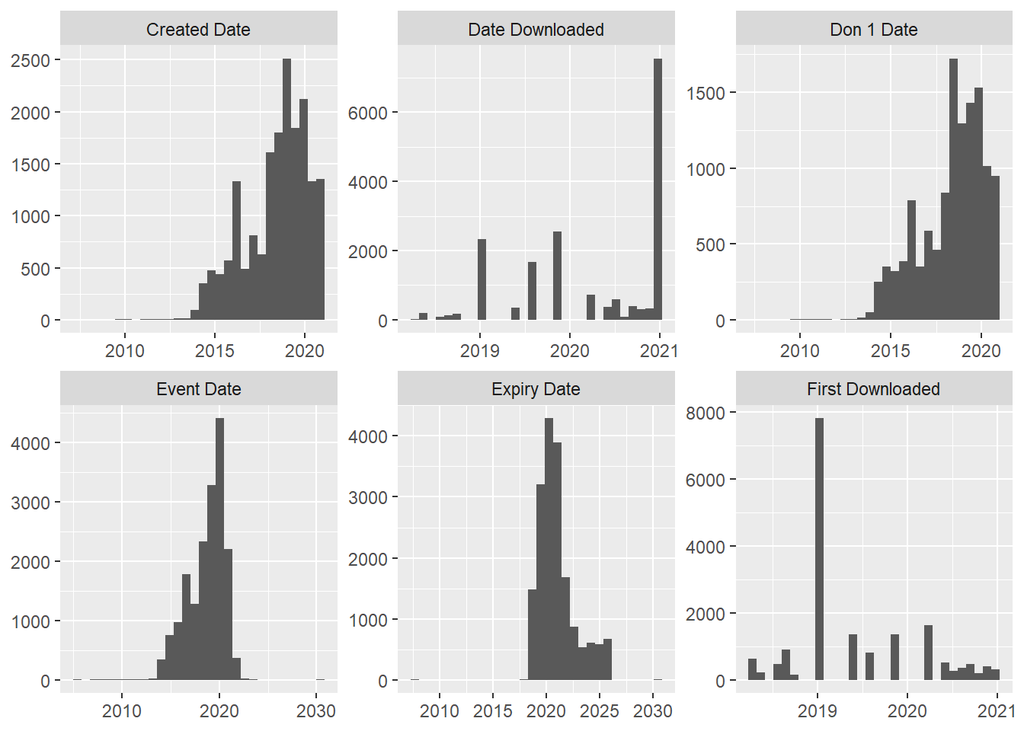

The first datasets were pulled from the API in 2018 which may explain the low number of fundraisers being created prior to 2016 as only active pages are pulled from the API.

### Donation Summary Statistics

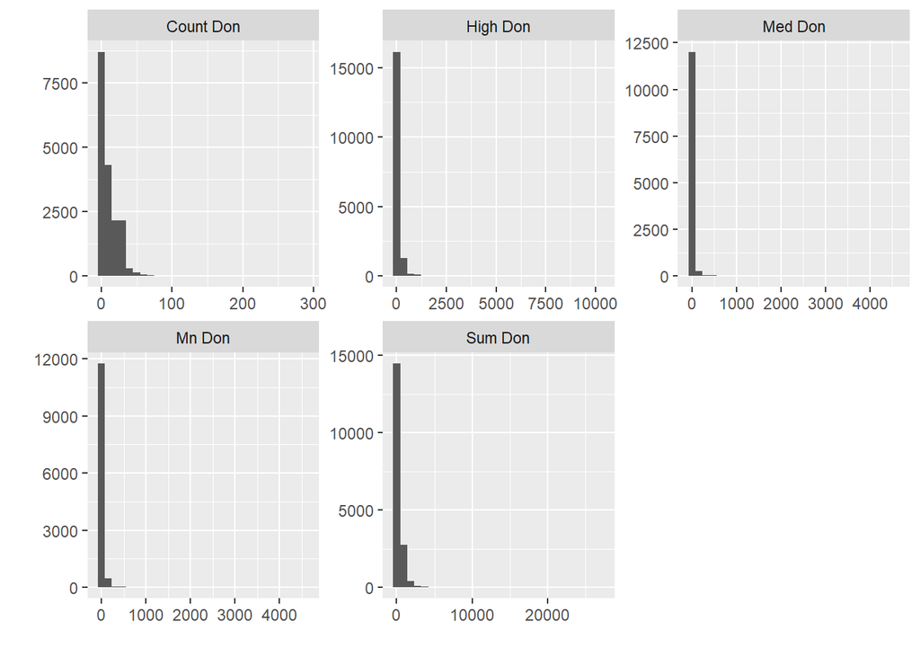

We see from our plots that our data is heavily impacted by outliers. In order to create plots that are easier to interpret we can attempt to remove the outliers which are present. For simiplicity, we will remove values in each column which are over the 99% percentile (in said column) with the value `NA`.

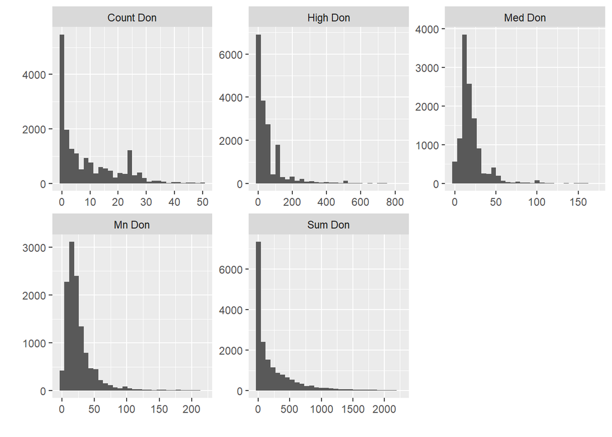

## What has fundraiser page creation been like over the past few years?

We can use our data to sum the total number of fundraisers created in each month. This data can then be used to visualize how fundraiser creation has varied over the past years.

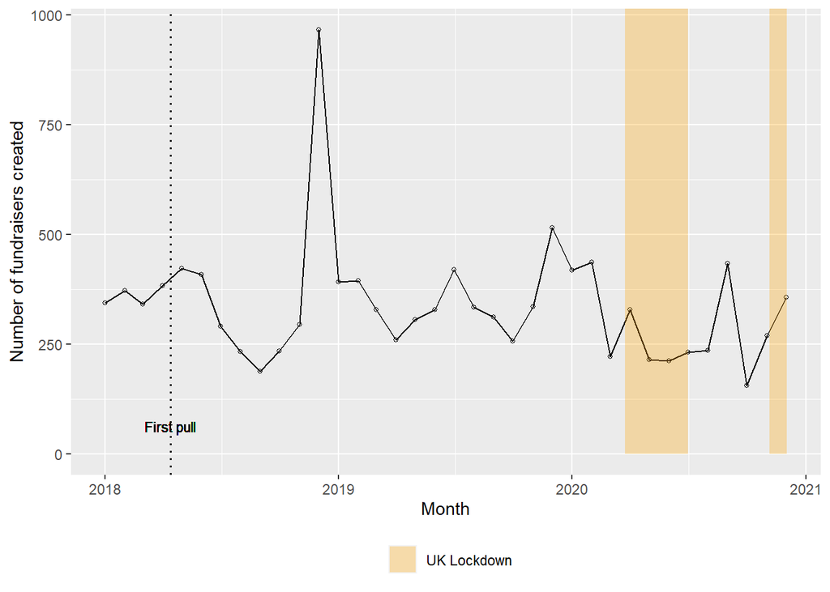

### Fundraisers for effective charities created in 2020

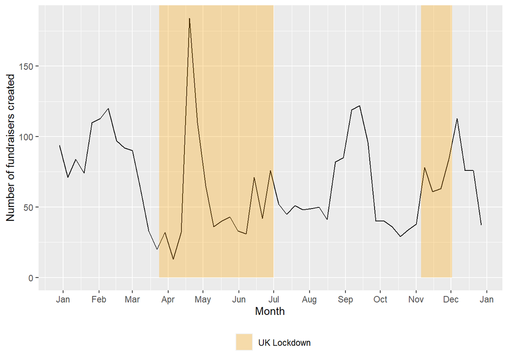

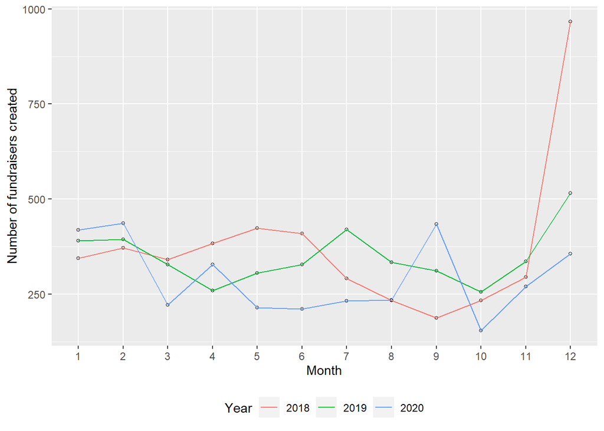

We can see a very large spike in fundraisers created during December 2018. By splitting fundraiser creation by charity we may be able to figure out what this spike came from:

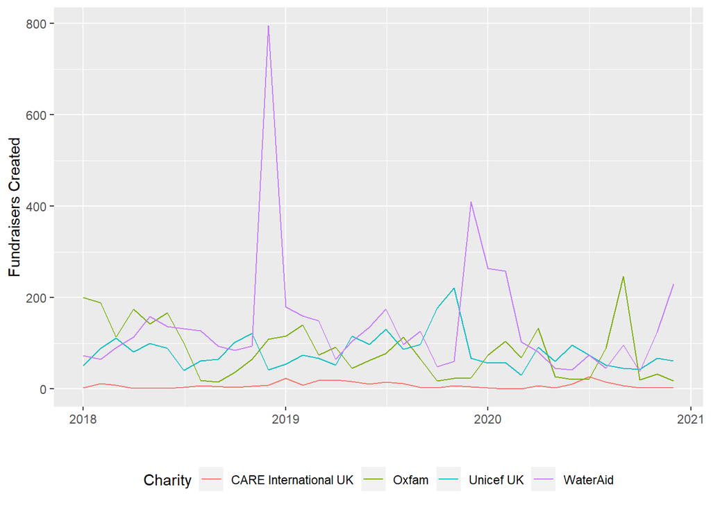

Looking at the above graph we can see that the spike in fundraiser creation in December 2018 came from fundraisers raising money for WaterAid. It may be useful to investigate the reason for this spike by looking at the most frequent events in that month.  
Note that we see a similar but less dramatic spike in December 2019.

WaterAid events created in December 2018

| Event Name | Count |
| --- | --- |
| Just Water 2019 | 740 |
| BMW Berlin Marathon 2019 | 10 |
| London Landmarks Half Marathon 2019 | 8 |
| London Marathon 2019 | 4 |

We see that the *Just Water 2019* event makes up for a considerable amount of the total fundraisers created in December 2018. If we look at December 2019 do we see this event dominating fundraiser creation again?

WaterAid events created in December 2019

| Event Name | Count |
| --- | --- |
| Just Water 2020 | 372 |
| Berlin Marathon 2021 | 5 |
| WaterAid Scotland Munro Challenge 2020 | 5 |
| Trek Nepal | 3 |

Indeed we do! Clearly this is a very popular event.

### Which charities have been the most popular in terms of fundraiser creation

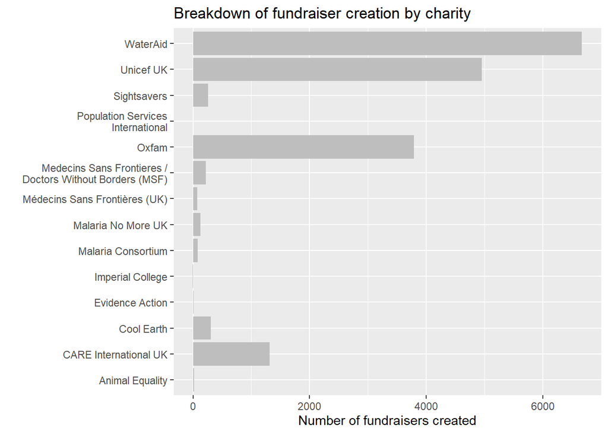

### Are the most popular charities the same for 2020?

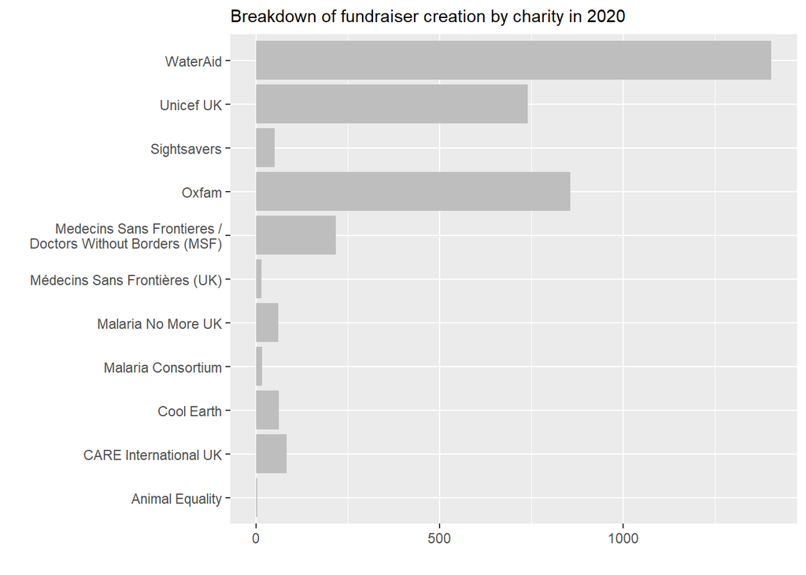

The above table shows the breakdown of fundraisers which have been created in 2020 by charity. The majority of fundraisers created in our sample of effective charities were for WaterAid, Oxfam and Unicef UK. Which follows the pattern from previous years.

### The state of monthly giving

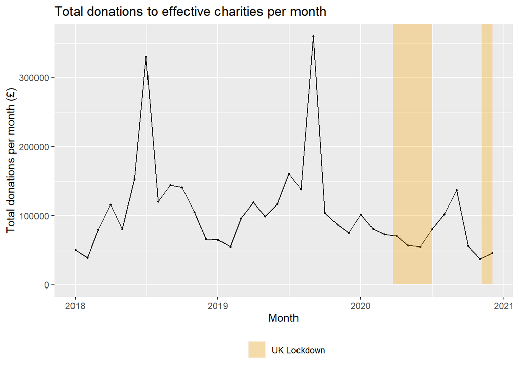

It seems as if there have been a couple of spikes with donations, we can investigate the cause for these. Possible causes for these particular months having such a high amount of total donations could be: * A large increase in the number of donations being made, potentially due to a particularly influential fundraising event * A change in the donating behaviour of individuals (this is less likely)

### Which charities were the most successful?

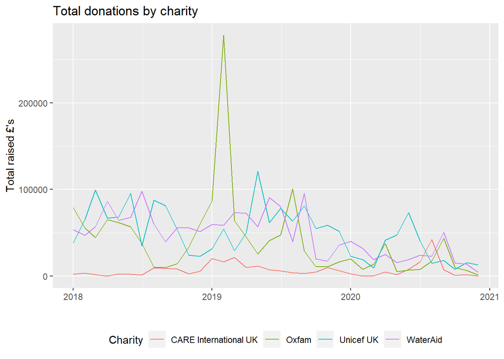

| charity_name | Total_raised | Mean | Median |
| --- | --- | --- | --- |
| Unicef UK | 1795174 | 610 | 190 |
| WaterAid | 1717005 | 338 | 50 |
| Oxfam | 1458719 | 479 | 100 |
| CARE International UK | 237170 | 838 | 290 |
| Medecins Sans Frontieres / Doctors Without Borders (MSF) | 102960 | 464 | 104 |
| Sightsavers | 87633 | 649 | 304 |
| Cool Earth | 81844 | 359 | 168 |
| Malaria Consortium | 36961 | 560 | 300 |
| Malaria No More UK | 20302 | 257 | 0 |
| Médecins Sans Frontières (UK) | 12945 | 219 | 90 |
| Animal Equality | 6702 | 419 | 112 |
| Evidence Action | 5478 | 548 | 334 |
| Imperial College | 450 | 225 | 225 |